# Analysis_Manoj

###### Gradient Boosting

```r
library(gbm)
# 1 Boosting-
boost.model=gbm(Price ~ ., data=final_df.train,
                 distribution="gaussian", n.trees=5000, interaction.depth=1)
#
#for the plot
par(mfrow=c(1,1))
#
#plot of training error
plot(boost.model$train.error, type="l", ylab="training error")
```

```r
# default vector of parameters
mai.old<-par()$mai
mai.old
#new vector
mai.new<-mai.old
#new space on the left
mai.new[2] <- 2.5
mai.new
#modify graphical parameters
par(mai=mai.new)

#relative influence plot
summary(boost.model, las=1, cBar=10)
#cBar defines how many variables
#back to orginal window
par(mai=mai.old)
```

```r
#test set prediction for every tree (1:5000)


yhat.boost=predict(boost.model, newdata=final_df.test, n.trees=1:5000)

# calculate the error for each iteration
#use 'apply' to perform a 'cycle for'
# the first element is the matrix we want to use, 2 means 'by column',
#and the third element indicates the function we want to calculate

err = apply(yhat.boost, 2, function(pred) mean((final_df.test$Price - pred)^2))
#
plot(err, type="l")
```

```r
# error comparison (train e test)
plot(boost.model$train.error, type="l")
lines(err, type="l", col=2)
#minimum error in test set
best=which.min(err)
abline(v=best, lty=2, col=4)
#
min(err) #minimum error
```

```r
# 2 Boosting- Deeper Trees and small lerning rate
boost.model=gbm(Price ~ ., data=final_df.train,
                 distribution="gaussian", n.trees=5000, interaction.depth=4, shrinkage=0.01)
#
#for the plot
par(mfrow=c(1,1))
#
#plot of training error
plot(boost.model$train.error, type="l", ylab="training error")
```

```r
summary(boost.model, las=1, cBar=10)

yhat.boost=predict(boost.model, newdata=final_df.test, n.trees=1:5000)

err = apply(yhat.boost, 2, function(pred) mean((final_df.test$Price - pred)^2))
#
plot(err, type="l")
```

```r
# error comparison (train e test)
plot(boost.model$train.error, type="l")
lines(err, type="l", col=2)
#minimum error in test set
best=which.min(err)
abline(v=best, lty=2, col=4)
#
min(err) #minimum error
```

PART2 ########################################

Need to modify the below code and see how it works because new columns are added

```r
library(forecast)
# initial auto-correlation
btc.price <- final_df$Price
Acf(final_df$Price)
pacf(final_df$Price, na.action = na.pass)
```

```r
# Handling missing values ----
# check for missing values
sum(is.na(btc.price))
```

```r
tt <- 1:NROW(final_df$Price)
plot(tt, final_df$Price, xlab="time", ylab="BTC Price", main="Distribution of btc prices over time", col=1, type="b", lty=1, pch=5, cex=0.6)
```

```r
# Normal Linear Model ----

# fitting linear model
fit <- lm(btc.price~tt)
summary(fit)
```

```r
# plotting regression fit
plot(tt, btc.price, xlab="time", ylab="BTC Price", main="distribution of btc prices over time", col=1, type="b", lty=1, pch=5, cex=0.6)
abline(fit, col=2)
```

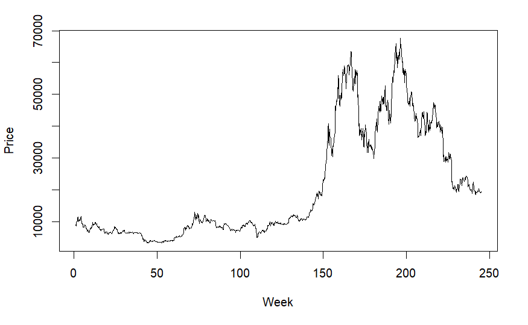

```r
# plotting time-series object
#ts.plot(btc.price.ts, type="l", col="red")
ts.plot(ts_data_train, col="black",xlab= "Week",ylab='Price')
```

```r
# fitting linear model on time-series object with just trend
fit.t <- tslm(ts_data_train~trend)
summary(fit.t)
```

```
Call:
tslm(formula = ts_data_train ~ trend)

Residuals:
   Min     1Q Median     3Q    Max
-23255  -8808  -2449   7001  35115

Coefficients:
              Estimate Std. Error t value Pr(>|t|)
(Intercept) -1150.9468   695.9711  -1.654   0.0984 .
trend          35.6758     0.9867  36.158   <2e-16 ***
---
Signif. codes:  0 ‘***’ 0.001 ‘**’ 0.01 ‘*’ 0.05 ‘.’ 0.1 ‘ ’ 1

Residual standard error: 12150 on 1219 degrees of freedom
Multiple R-squared:  0.5175,    Adjusted R-squared:  0.5171
F-statistic:  1307 on 1 and 1219 DF,  p-value: < 2.2e-16
```

```r
# plotting time-series object
#ts.plot(btc.price.ts, type="l", col="red")
ts.plot(ts_data_train, col="black",xlab= "Week",ylab='Price')

# fitting linear model on time-series object with just trend
fit.t <- tslm(ts_data_train~trend)
summary(fit.t)
```

```r
# plotting time-series regression line
ts.plot(ts_data, xlab="Week", ylab="BTC price", main="Plotting time-series regression line of BTC prices over time", col=2)
lines(fitted(fit.t), col=1)
```

```r
##check the residuals if they are auto-correlated by using Durbin Watson test
dwtest(fit.t)
```

```r
##Finding the residuals
res.trend<- residuals(fit.t)

#Plotting the residuals
plot(res.trend,xlab="Time", ylab="residuals", col=2 )
title('Residual Plot')
```

```r
acf(res.trend)
```

```r
tslmf= forecast(fit.t, h=10)
```

```r
AIC(fit.t)

# Calculate the absolute percentage error for each data point
errors <- abs((tslmf$mean - ts_data_test[1:10]) / ts_data_test[1:10])

# Calculate the mean absolute percentage error
mape <- mean(errors) * 100

# Print the result
print(mape)


# Calculate the squared error for each data point
squared_errors <- (tslmf$mean - ts_data_test[1:10])^2

# Calculate the mean squared error
mse <- mean(squared_errors)

# Take the square root of the mean squared error
rmse <- sqrt(mse)

# Print the result
print(rmse)
```

```r
# linear model with both trend and seasonality
fit.ts <- tslm(ts_data~trend+season)
summary(fit.ts)
```

```r
ts.plot(btc.price.ts, xlab="time", ylab="BTC price", main="Distribution of BTC prices over time", col=2)
lines(fitted(fit.ts), col=1)
```

```r
res.ts <- residuals(fit.ts)
plot(res.ts, col=2)
```

```r
acf(res.ts)
```

```r
#Bass Model 1----

# Bass Model ----
subset2 <- ts_data_train

## visualizing cumulative sum for the bass model
#plot(cumsum(subset2), type="b")

#plot(subset2, type="b", xlab="Day", ylab="BTC price", pch=16, xaxt="n", lty=3, cex=0.6)
#axis(1, at = seq(1,length(subset1),by=35), labels=final_df$Date[seq(700,(699+length(subset1)),by=35)])
```

```r
#Bass Model 1----

# Bass Model ----
subset2 <- ts_data_train

## visualizing cumulative sum for the bass model
#plot(cumsum(subset2), type="b")

#plot(subset2, type="b", xlab="Day", ylab="BTC price", pch=16, xaxt="n", lty=3, cex=0.6)
#axis(1, at = seq(1,length(subset1),by=35), labels=final_df$Date[seq(700,(699+length(subset1)),by=35)])
```

```r
Acf(subset2)
```

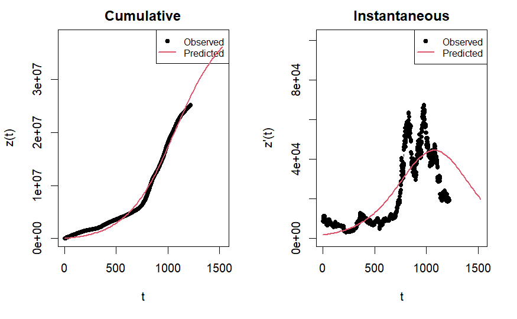

```r
# applying bass model
bm_prices <- BM(subset2, display=T)
```

```r
summary(bm_prices)
```

```
Call: ( Standard Bass Model )

  BM(series = subset2, display = T)

Residuals:
     Min.  1st Qu.   Median     Mean  3rd Qu.     Max.
-1606864  -102066   517648   227734   855398  1008903

Coefficients:
```

|  | Estimate | Std.Error | Lower | Upper | p-value |  |
| --- | --- | --- | --- | --- | --- | --- |
| m | 4.144759e+07 | 9.117482e+05 | 3.966059e+07 | 4.323458e+07 | 1.21e-264 | *** |
| p | 4.326765e-05 | 7.683358e-07 | 4.176174e-05 | 4.477356e-05 | 0.00e+00 | *** |
| q | 4.212092e-03 | 6.277418e-05 | 4.089056e-03 | 4.335127e-03 | 0.00e+00 | *** |

```
---
 Signif. codes:  0 '***' 0.001 '**' 0.01 '*' 0.05 '.' 0.1 ' ' 1

 Residual standard error  763602  on  1218  degrees of freedom
 Multiple R-squared:   0.9950559  Residual squared sum:  7.746917e+14
```

```r
# applying bass model
bm_prices <- BM(subset2, display=T)
summary(bm_prices)
```

```r
# prediction
pred_bmprices <- predict(bm_prices, newx = (1:(10+length(subset2))))
pred.instprices <- make.instantaneous(pred_bmprices)


plot(pred.instprices, col=2, xaxt="n", ylim = c(0,70000),pch=16, lty=3, cex=0.6, xlab="Date", ylab = "Price")
title(expression(paste('Bass Model fitted from 14/10/2020 to 16/06/2021(175 days)','\n',' and forecasted price on next 100 days')), font.main = 2, line = 2, col.main = "blue")
axis(1, at = seq(1,100+length(subset1),by=35), labels=final_df$Date[seq(700,(799+length(subset1)),by=35)])
abline(v = 175, col = "red")
text(175, "Bass Model applied to data up until th red line", col = "red", pos = 4, offset = 0.5)
lines(final_df$Price[700:975], type="b", xlab="Day", ylab="BTC price", pch=16, lty=3, cex=0.6)
```

```r
plot(residuals(bm_prices), xlab='No. of Days',ylab ='Residuals',pch=16, lty=3, cex=0.6)
title('Residusal Plot for Bass Model')
```

```r
###we estimate the model with less than 50% of the data

bm_prices50<-BM(subset1[1:135],display = T)
summary(bm_prices50)

pred_bm_prices50<- predict(bm_prices50, newx=c(1:398))
pred.instprices50<- make.instantaneous(pred_bm_prices50)


plot(subset1, type="b", xlab="Day", ylab="BTC price", pch=16, lty=3, cex=0.6)
#, xaxt="n"
#axis(1, at = seq(1,length(subset1),by=20), labels=btc$Date[seq(1001,(1000+length(subset1)),by=20)])
lines(pred.instprices50, lwd=2, col=2)
```

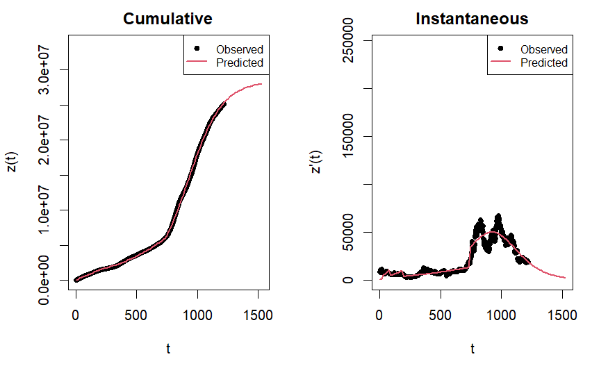

```r
#(m, p, q are from Bass Model because they can be reasonable starting points)
# rectangular shock (a1 - begin of shock, b1 - end of shock, c1 - intensity of shock(a1 < b1, c1 can be +ve or -ve))
GMBr2btc <- GBM(subset2, shock = "rett", nshock = 3, prelimestimates = c(4.144759e+07, 4.326765e-05, 4.212092e-03,60,75,0.3, 85, 100,-0.3,110, 130,-0.4))
```

```r
#
summary(GMBr2btc)
```

```
Call: ( Generalized Bass model with 3  Rectangular  shock )

  GBM(series = subset2, shock = "rett", nshock = 3, prelimestimates = c(41447590,
    4.326765e-05, 0.004212092, 60, 75, 0.3, 85, 100, -0.3, 110,
    130, -0.4))

Residuals:
      Min.   1st Qu.    Median      Mean   3rd Qu.      Max.
-424428.6 -100708.9    -730.6   -1612.8   96011.5  506628.2

Coefficients:
```

|  | Estimate | Std.Error | Lower | Upper | p-value |  |
| --- | --- | --- | --- | --- | --- | --- |
| m | 2.843514e+07 | 6.431260e+04 | 2.830909e+07 | 2.856119e+07 | 0.00e+00 | *** |
| p | 1.164881e-05 | 1.465236e-05 | -1.706930e-05 | 4.036692e-05 | 4.27e-01 |  |
| q | 7.060083e-03 | 4.803831e-05 | 6.965930e-03 | 7.154236e-03 | 0.00e+00 | *** |
| a1 | -4.965613e+01 | 7.524899e+01 | -1.971415e+02 | 9.782918e+01 | 5.09e-01 |  |
| b1 | 7.785533e+01 | 8.625375e+00 | 6.094991e+01 | 9.476075e+01 | 6.82e-19 | *** |
| c1 | 1.215063e+00 | 4.518021e-01 | 3.295472e-01 | 2.100579e+00 | 7.26e-03 | ** |
| a2 | 1.687986e+02 | 3.691848e+06 | -7.235720e+06 | 7.236057e+06 | 1.00e+00 |  |
| b2 | 1.899999e+01 | 9.165115e+05 | -1.796310e+06 | 1.796348e+06 | 1.00e+00 |  |
| c2 | -1.075982e+00 | 3.102259e+04 | -6.080423e+04 | 6.080208e+04 | 1.00e+00 |  |
| a3 | 1.874389e+02 | 5.661705e+00 | 1.763421e+02 | 1.985356e+02 | 1.29e-171 | *** |

[output cut: 2 more lines]

```
---
 Signif. codes:  0 '***' 0.001 '**' 0.01 '*' 0.05 '.' 0.1 ' ' 1

 Residual standard error  155297.8  on  1209  degrees of freedom
 Multiple R-squared:   0.9996094  Residual squared sum:  2.94264e+13
```

```r
###Comparison between models (cumulative)

plot(cumsum(subset1), type="b", xlab="Day", ylab="BTC price", pch=16, lty=3, xaxt="n", cex=0.6)
axis(1, at = seq(1,length(subset1),by=20), labels=btc$Date[seq(1001,(1000+length(subset1)),by=20)])
lines(pred_bmprices, lwd=2, col=2)
lines(pred_bm_prices50, lwd=2, col=3)
```

```r
#(m, p, q are from Bass Model because they can be reasonable starting points)
# rectangular shock (a1 - begin of shock, b1 - end of shock, c1 - intensity of shock(a1 < b1, c1 can be +ve or -ve))
GMBr2btc <- GBM(subset2, shock = "rett", nshock = 3, prelimestimates = c(4.144759e+07, 4.326765e-05, 4.212092e-03,60,75,0.3, 85, 100,-0.3,110, 130,-0.4))
#
summary(GMBr2btc)
```

```r
# cumulative predictions
pred_GMBr2btc<- predict(GMBr2btc, newx = (1:(10+leng(subset2))))
```

```
Error in leng(subset2) : could not find function "leng"
```

```r
plot(residuals(GMBr2btc), xlab='No. of Days',ylab ='Residuals',pch=16, lty=3, cex=0.6)
title('Residusal Plot for GBM')
```

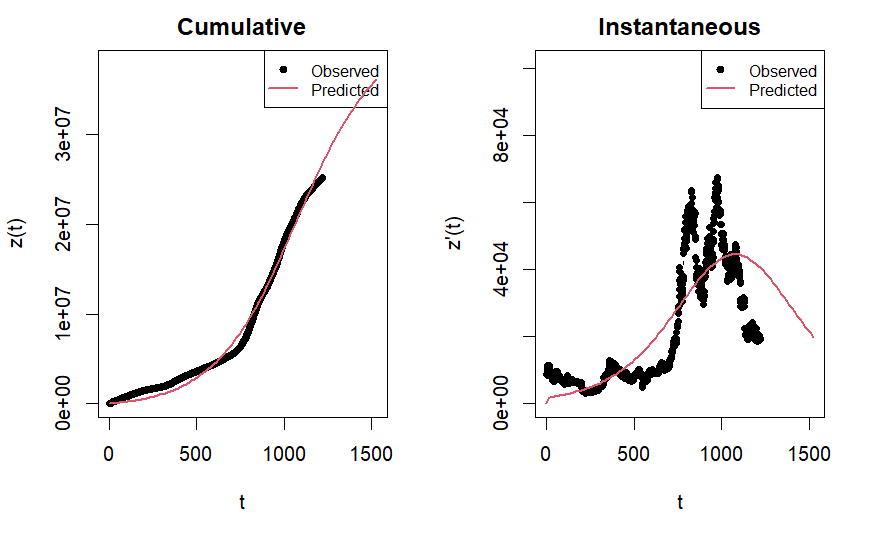

```r
GGM_btc<- GGM(subset2, prelimestimates=c(4.144759e+07, 0.001, 0.01, 4.326765e-05, 4.212092e-03))
```

```r
summary(GGM_btc)
```

```
Call: ( Guseo Guidolin Model )

  GGM(series = subset2, prelimestimates = c(41447590, 0.001, 0.01,
    4.326765e-05, 0.004212092))

Residuals:
     Min.  1st Qu.   Median     Mean  3rd Qu.     Max.
-1606880  -102093   517621   227725   855372  1008921

Coefficients:
```

|  | Estimate | Std.Error | Lower | Upper | p-value |  |
| --- | --- | --- | --- | --- | --- | --- |
| K | 4.144808e+07 | 9.126276e+05 | 3.965936e+07 | 4.323679e+07 | 3.62e-264 | *** |
| pc | 3.503309e-01 | 1.469323e+03 | -2.879470e+03 | 2.880171e+03 | 1.00e+00 |  |
| qc | 1.879323e+00 | 6.062532e+03 | -1.188047e+04 | 1.188422e+04 | 1.00e+00 |  |
| ps | 4.326814e-05 | 7.689616e-07 | 4.176100e-05 | 4.477528e-05 | 0.00e+00 | *** |
| qs | 4.212048e-03 | 6.282557e-05 | 4.088912e-03 | 4.335184e-03 | 0.00e+00 | *** |

```
---
 Signif. codes:  0 '***' 0.001 '**' 0.01 '*' 0.05 '.' 0.1 ' ' 1

 Residual standard error  763604.6  on  1216  degrees of freedom
 Multiple R-squared:   0.9897177  Residual squared sum:  7.746917e+14
```

Let’s see what happened on January 8th,2021 which lead to rise of btc suddenly?

From August 2020 to February 2021 ther is second wave of Covid-19 due to which many has invested their money in notable precious metals like Gold and Bitcoin to during the uncertain times to diversify their portfolio which lead to drastc rise of bitcoin.

```r
pred_GGM_btc<- predict(GGM_btc, newx=1:(10+length(subset2)))
pred_GGM_btc.inst<- make.instantaneous(pred_GGM_btc)
```

```r
######GGM

subset1 <- final_df$Price[700:875]
```

```r
GGM_btc<- GGM(subset2, prelimestimates=c(4.144759e+07   , 0.001, 0.01, 4.326765e-05, 4.212092e-03))
summary(GGM_btc)
```

```r
pred_GGM_btc<- predict(GGM_btc, newx=1:(10+length(subset2)))
pred_GGM_btc.inst<- make.instantaneous(pred_GGM_btc)
```

```r
plot(final_df$Price[700:975], type="b", ylim = c(0,70000), xlab="Day", ylab="BTC price", pch=16, lty=3,xaxt ="n", cex=0.6)
axis(1, at = seq(1,length(final_df$Price[700:975]),by=35),
labels=final_df$Date[seq(700,(799+length(subset1)),by=35)])
abline(v = 175, col = "blue")
text(5, "BM,GBM and GGM fitted to data up until the blue line", col = "blue",adj =-2)
lines(pred_GMBr2btc.inst, lwd=2, col=4)
lines(pred.instprices, lwd=2, col=3)
lines(pred_GGM_btc.inst, lwd=2, col=2)
title(expression(paste('BM,GBM and GGM fitted from 14/10/2020 to 16/06/2021(175 days)','\n',' and forecasted price on next 100 days')), font.main = 1, line = 2, col.main = "blue")

abline(v= 62, col ='brown')
abline(v= 92, col ='brown')

text(175, "Increased fears of Covid 2nd wave around Jan 9 and Feb 19,2021", col = "brown",adj= 0)

# Add a legend to the plot
legend("topright", legend = c("BM","GGM", "GBM"), col = c("red", "green","blue"), lty = 1, lwd = 2)
```

```r
###Analysis of residuals
res_GGM_btc<- residuals(GGM_btc)
plot(res_GGM_btc)
lines(res_GGM_btc, col=2, lwd=2)
acf(res_GGM_btc, plot=T)
```

```r
### We Perform a competition study between BTC and ETH prices

year<- seq(1,length(btc$Date[1001:1300]))
norm_btc <- btc.price[1001:1300]/max(btc.price[1001:1300])
norm_eth <- eth.price[1001:1300]/max(eth.price[1001:1300])

###make a plot of the two series
plot(year,norm_btc,xlab="year", ylab="Price Distribution",   type= "b", pch=16, lty=3, cex=0.7, col ='black',ylim = c(0,1))
points(year,norm_eth, type= "b", pch=16, lty=3, cex=0.7, col='blue')
```

```r
###estimate the UCRCD (with delta and gamma)
ucrcdNR<- UCRCD(norm_btc,norm_eth, display=T)
summary(ucrcdNR)
plot.Dimora(ucrcdNR)
```

```r
##we make a plot of the UCRCD model

plot(year,norm_btc,xlab="year", ylab="Price Distribution",   type= "b", pch=16, lty=3, cex=0.7, col ='black',ylim = c(0,1), sub="The price of ETH grew as a result of investments made with money taken out of BTC market.",cex.lab = 0.1, )
points(year,norm_eth, type= "b", pch=16, lty=3, cex=0.7, col='blue')


lines(year, (ucrcdNR$fitted.i[[1]]), lwd=2, col=1)
lines(year, (ucrcdNR$fitted.i[[2]]), lwd=2, col=2)


###we also add a line and some text within the plot
abline(v=272, lty=2)
#text(50, 0.8, pos=1, "Money withdrawn from BTC is invested in ETH incresed price of it ")
```

```r
##Time series analysis: linear regression, ARIMA and ARIMAX models

library(fpp2)
library(forecast)
library(lmtest)
```

```r
#Linear regression with trend and seasonality for subset of data

plot(subset1, type="b", xlab="Day", ylab="BTC price", pch=16, lty=3, xaxt="n", cex=0.6)
axis(1, at = seq(1,length(subset1),by=20), labels=btc$Date[seq(1001,(1000+length(subset1)),by=20)])
Acf(subset1)
pacf(subset1)
```